# How to make Beautiful Ruby Plots with Galaaz

Rodrigo Botafogo

Daniel Mossé - University of Pittsburgh

November 19th, 2018 (narrative updated for Galaaz 2.0, 2026)

According to Wikipedia “Ruby is a dynamic, interpreted, reflective, object-oriented, general-purpose programming language. It was designed and developed in the mid-1990s by Yukihiro”Matz” Matsumoto in Japan.” It reached high popularity with the development of Ruby on Rails (RoR) by David Heinemeier Hansson. RoR is a web application framework first released around 2005. It makes extensive use of Ruby’s metaprogramming features. With RoR, Ruby became very popular. According to [Ruby’s ranking in the TIOBE index](https://www.tiobe.com/tiobe-index/ruby/) it **peaked** in popularity around 2008, then declined until 2015 when it started picking up again. As of the original publication date (November 2018), TIOBE placed Ruby around 16th among languages.

Python, often grouped with Ruby as a high-level scripting language, ranked higher in that same snapshot. Ruby is often criticized for its focus on web applications. But Ruby can do [much more](https://github.com/markets/awesome-ruby) than just web applications. Yet, for scientific computing, Ruby lags behind Python and R. Python combines web frameworks such as Django with NumPy, pandas, SciPy, and **a very large ecosystem** of domain-specific packages. R is a free software environment for statistical computing and graphics with thousands of libraries for data analysis.

Until recently, there was no real perspective for Ruby to bridge this gap. Implementing a complete scientific computing infrastructure would take too long.

**Galaaz 2.0** supports **[JRuby](https://www.jruby.org/)** or **CRuby** equally and drives **GNU R**—the same R distribution used for data science everywhere. A **bridge** evaluates R from Ruby and exchanges data between the two processes so that, from Ruby, you call R functions and work with R objects using familiar Ruby syntax. In other words, a Ruby programmer can use the capabilities of R without memorizing all of R’s syntax for day-to-day tasks.

An **earlier line of work** used Oracle’s **GraalVM** with **TruffleRuby** and **FastR** so that Ruby and R could share one JVM runtime. That stack is **no longer** what Galaaz targets; today’s Galaaz is developed and tested with **JRuby or CRuby + GNU R** (see the project manual for setup and command-line tools).

Library wrapping is a common way to bring features from one language into another. To improve performance, Python often wraps more efficient C libraries. For the Python developer, the existence of such C libraries is hidden. The problem with library wrapping is that for any new library, there is the need to handcraft a new wrapper.

Galaaz, instead of wrapping a single C or R library, wraps the whole R language in Ruby. Doing so, all thousands of R libraries are available immediately to Ruby developers without any new wrapping effort.

To show the power of Galaaz, we show in this article how Ruby can use R’s ggplot2 library **transparently**, bringing to Ruby the power of high-quality scientific plotting. We also show that migrating from R to Ruby with Galaaz is a matter of small syntactic changes. By using Ruby, the R developer can use all of Ruby’s powerful object-oriented features. Also, with Ruby, it becomes much easier to move code from the analysis phase to the production phase.

In this article we will explore the R ToothGrowth dataset. To illustrate, we will create some boxplots. A primer on boxplot is available in [this article](https://towardsdatascience.com/understanding-boxplots-5e2df7bcbd51).

We will also create a Corporate Template ensuring that plots will have a consistent visualization. This template is built using a Ruby module. There is a way of building ggplot themes that will work the same as the Ruby module. Yet, writing a new theme requires specific knowledge on theme writing. Ruby modules are standard to the language and don’t need special knowledge.

[Here](https://towardsdatascience.com/ruby-plotting-with-galaaz-an-example-of-tightly-coupling-ruby-and-r-in-graalvm-520b69e21021) is an older article (GraalVM-era Galaaz) with a scatter plot in Ruby; the **ideas** still apply under Galaaz 2.0 with JRuby or CRuby and GNU R.

# 1 gKnit

*Knitr* is an application that converts text written in rmarkdown to many different output formats. For instance, a writer can convert an rmarkdown document to HTML, LaTeX, Word, and many other formats. R Markdown documents can contain text and *code chunks*. knitr formats code chunks in a shaded box in the output document. It also executes the code chunks and formats the output in a white box. Every line of output from the execution code is preceded by ‘##’.

Knitr allows code chunks to be in R, Python, Ruby and dozens of other languages. Yet, while R and Python chunks can share data, in other languages, chunks are independent. This means that a variable defined in one chunk cannot be used in another chunk.

With *gKnit* Ruby code chunks can share data.

# 2 Exploring the Dataset

Let’s start by exploring our selected dataset. ToothGrowth is an R dataset. A dataset is like a simple Excel spreadsheet, in which each column has only one type of data. For instance one column can have float, the other integer, and a third strings. This dataset analyzes the length of odontoblasts (cells responsible for tooth growth) in 60 guinea pigs, where each animal received one of three dose levels of Vitamin C (0.5, 1, and 2 mg/day) by one of two delivery methods, orange juice OJ or ascorbic acid (a form of vitamin C and coded as VC).

The ToothGrowth dataset contains three columns: ‘len’, ‘supp’ and ‘dose’. Let’s take a look at a few rows of this dataset. In Galaaz, R variables are accessed by using the corresponding Ruby symbol with the tilde (`~`) operator. Note in the following chunk that ‘ToothGrowth’ is the R variable and Ruby’s ‘tooth_growth’ is assigned the value of ‘~R[:ToothGrowth]’.

```ruby
# Read the R ToothGrowth variable and assign it to the
# Ruby instance variable tooth_growth that will be
# available to all Ruby chunks in this document.
tooth_growth = ~R[:ToothGrowth]
# print the first few elements of the dataset
puts tooth_growth.head
```

```
##    len supp dose
## 1  4.2   VC  0.5
## 2 11.5   VC  0.5
## 3  7.3   VC  0.5
## 4  5.8   VC  0.5
## 5  6.4   VC  0.5
## 6 10.0   VC  0.5
```

Great! We’ve managed to read the ToothGrowth dataset and take a look at its elements. We see here the first 6 rows of the dataset. To access a column, follow the dataset name with a dot (‘.’) and the name of the column. Also use dot notation to chain methods in usual Ruby style.

```ruby
# Access the tooth_growth 'len' column and print the first few
# elements of this column with the 'head' method.
puts tooth_growth.len.head
```

```
## [1]  4.2 11.5  7.3  5.8  6.4 10.0
```

The ‘dose’ column contains a numeric value with either, 0.5, 1 or 2, although the first 6 rows as seen above only contain the 0.5 values. Even though those are number, they are better interpreted as a [factor or category](https://swcarpentry.github.io/r-novice-inflammation/12-supp-factors/). So, let’s convert our ‘dose’ column from numeric to ‘factor’. In R, the function ‘as.factor’ is used to convert data in a vector to factors. To use this function from Galaaz the dot (‘.’) in the function name is substituted by ’__’ (double underline). The function ‘as.factor’ becomes ’R.as__factor’ or just ’as__factor’ when chaining.

```ruby
# convert the dose to a factor
tooth_growth.dose = tooth_growth.dose.as__factor
```

Let’s explore some more details of this dataset. In particular, let’s look at its dimensions, structure and summary statistics.

```ruby
puts tooth_growth.dim
```

```
## [1] 60  3
```

This dataset has 60 rows, one for each subject and 3 columns, as we have already seen.

Note that we do not need to call ‘puts’ when using the ‘str’ function. This functions does not return anything and prints the structure of the dataset as a side effect.

```ruby
tooth_growth.str
```

[output not shown]

Observe that both variables ‘supp’ and ‘dose’ are factors. The system made variable ‘supp’ a factor automatically, since it contais two strings OJ and VC.

Finally, using the summary method, we get the statistical summary for the dataset

```ruby
puts tooth_growth.summary
```

```
##       len        supp     dose
##  Min.   : 4.20   OJ:30   0.5:20
##  1st Qu.:13.07   VC:30   1  :20
##  Median :19.25           2  :20
##  Mean   :18.81
##  3rd Qu.:25.27
##  Max.   :33.90
```

# 3 Doing the Data Analysis

## 3.1 Quick plot for seing the data

Let’s now create our first plot with the given data by accessing ggplot2 from Ruby. For Rubyists that have never seen or used ggplot2, here is the description of ggplot found in its home page:

> “ggplot2 is a system for declaratively creating graphics, based on *The Grammar of Graphics*. You provide the data, tell ggplot2 how to map variables to aesthetics, what graphical primitives to use, and it takes care of the details.”

This description might be a bit cryptic and it is best to see it at work to understand it. Basically, in the *grammar of graphics* developers add layers of components such as grid, axis, data, title, subtitle and also graphical primitives such as *bar plot*, *box plot*, to form the final graphics.

In order to make a plot, we use the ‘ggplot’ function to the dataset. In R, this would be written as `ggplot(<dataset>, ...)`. Galaaz gives you the flexibility to use either `R.ggplot(<dataset>, ...)` or `<dataset>.ggplot(...)`. In the graph specification below, we use the second notation that looks more like Ruby.  
ggplot uses the ‘aes’ method to specify x and y axes; in this case, the ‘dose’ on the $x$ axis and the ‘length’ on the $y$ axis: ‘E.aes(x: :dose, y: :len)’. To specify the type of plot add a geom to the plot. For a boxplot, the geom is R.geom_boxplot.

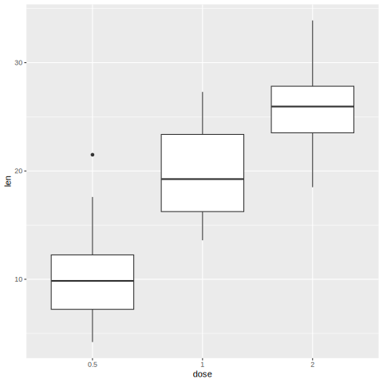

```ruby
require 'ggplot'

e = tooth_growth.ggplot(E.aes(x: :dose, y: :len))
print e + R.geom_boxplot
```

## 3.2 Facetting the plot

This first plot shows a trend, but our data has information about two different forms of delivery method, either by Orange Juice OJ or by Vitamin C VC. Let’s then try to create a plot that helps us discern the effect of each delivery method. This next plot is a *facetted* plot where each delivery method gets is own plot. On the left side, the plot shows the OJ delivery method. On the right side, we see the VC delivery method. To obtain this plot, we use the ‘R.facet_grid’ function, that automatically creates the facets based on the delivery method factors. The parameter to the ‘facet_grid’ method is a [*formula*](https://thomasleeper.com/Rcourse/Tutorials/formulae.html).

In Galaaz we give programmers the flexibility to use two different ways to write formulas. In the first way, we use Ruby expressions and the ‘.til’ function. The formula ‘x ~ y’, becomes ‘R[:x].til :y’. More information on expressions can be found in [Galaaz Manual](https://www.rubydoc.info/gems/galaaz/).

Another way of writing a formula is to use the ‘formula’ function with the actual formula as a string. The formula `x ~ y` in R can be written as `R.formula("x ~ y")`. For more complex formulas, the use of the ‘formula’ function is preferred.

The formula `R[:all].til :supp` indicates to the ‘facet_grid’ function that it needs to facet the plot based on the `supp` variable and split the plot vertically. Changing the formula to `R[:supp].til :all` would split the plot horizontally.

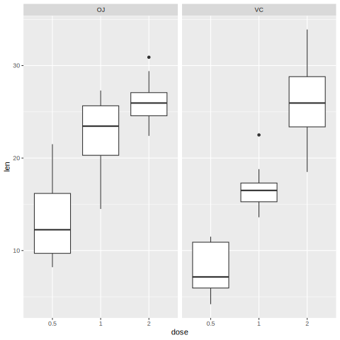

```ruby
base_tooth = tooth_growth.ggplot(E.aes(x: :dose, y: :len, group: :dose))

bp = base_tooth + R.geom_boxplot +
      # Split in vertical direction
      R.facet_grid(R[:all].til :supp)

puts bp
```

It now becomes clear that although both methods of delivery have a direct impact on tooth growth, method (OJ) is non-linear having a higher impact with smaller doses of ascorbic acid and reducing it’s impact as the dose increases. With the (VC) approach, the impact seems to be more linear.

## 3.3 Adding Color

If we were writing about data analysis, we would make a better analysis of the trends and improve the statistical analysis. But here we are interested in working with ggplot in Ruby. So, let’s add some color to this plot to make the trend and comparison more visible. In the following plot, the boxes are color coded by dose. To add color, it is enough to add `fill: :dose` to the aesthetic of boxplot. With this command each ‘dose’ factor gets its own color.

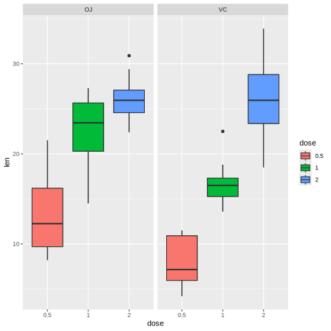

```ruby
bp = bp + R.geom_boxplot(E.aes(fill: :dose))
puts bp
```

Facetting helps us compare the general trends for each delivery method. Adding color allow us to compare specifically how each dosage impacts the tooth growth. It is possible to observe that with smaller doses, up to 1mg, OJ performs better than VC (red color). For 2mg, both OJ and VC have the same median, but OJ is less disperse (blue color). For 1mg (green color), OJ is significantly bettern than VC. By this very quick visual analysis, it seems that OJ is a better delivery method than VC.

## 3.4 Clarifying the data

Boxplots give us a nice idea of the distribution of data, but looking at those plots with large colored boxes leaves us wondering what else is going on. According to Edward Tufte in Envisioning Information:

> Thin data rightly prompts suspicions: “What are they leaving out? Is that really everything they know? What are they hiding? Is that all they did?” Now and then it is claimed that vacant space is “friendly” (anthropomorphizing an inherently murky idea) but *it is not how much empty space there is, but rather how it is used. It is not how much information there is, but rather how effectively it is arranged.*

And he states:

> A most unconventional design strategy is revealed: *to clarify, add detail.*

Let’s use this wisdom and add yet another layer of data to our plot, so that we clarify it with detail and do not leave large empty boxes. In this next plot, we add data points for each of the 60 pigs in the experiment. For that, add the function ‘R.geom_point’ to the plot.

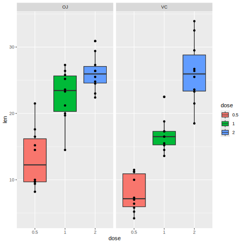

```ruby
# Split in vertical direction
bp = bp + R.geom_point

puts bp
```

Now we can see the actual distribution of all the 60 subjects. Actually, this is not totally true. We have a hard time seing all 60 subjects. It seems that some points might be placed one over the other hiding useful information.

But no sweat! Another layer might solve the problem. In the following plot a new layer called ‘geom_jitter’ is added to the plot. Jitter adds a small amount of random variation to the location of each point, and is a useful way of handling overplotting caused by discreteness in smaller datasets. This makes it easier to see all of the points and prevents data hiding. We also add color and change the shape of the points, making them even easier to see.

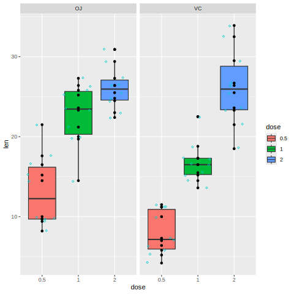

```ruby
# Split in vertical direction
puts bp + R.geom_jitter(shape: 23, color: "cyan3", size: 1)
```

Now we can see all 60 points in the graph. We have here a much higher information density and we can see outliers and subjects distribution.

# 4 Preparing the Plot for Presentation

We have come a long way since our first plot. As we already said, this is not an article about data analysis and the focus is on the integration of Ruby and ggplot. So, let’s assume that the analysis is now done. Yet, ending the analysis does not mean that the work is done. On the contrary, the hardest part is yet to come!

After the analysis it is necessary to communicate it by making a final plot for presentation. The last plot has all the information we want to share, but it is not very pleasing to the eye.

## 4.1 Improving Colors

Let’s start by trying to improve colors. For now, we will not use the jitter layer. The previous plot has three bright colors that have no relashionship between them. Is there any obvious, or non-obvious for that matter, interpretation for the colors? Clearly, they are just random colors selected automatically by our software. Although those colors helped us understand the data, for a final presentation random colors can distract the viewer.

```ruby
bp = bp +
     R.scale_fill_manual(
       values: R.c("cyan", "deepskyblue", "deepskyblue4"),
       breaks: R.c("2", "1", "0.5"))

puts bp
```

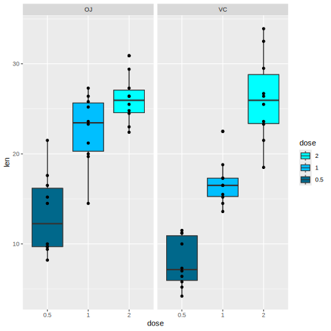

## 4.2 Violin Plot and Jitter

The boxplot with jitter did look a bit overwhelming. The next plot uses a variation of a boxplot known as a *violin plot* with jittered data.

[From Wikipedia](https://en.wikipedia.org/wiki/Violin_plot)

> A violin plot is a method of plotting numeric data. It is similar to a box plot with a rotated kernel density plot on each side.

> A violin plot has four layers. The outer shape represents all possible results, with thickness indicating how common. (Thus the thickest section represents the mode average.) The next layer inside represents the values that occur 95% of the time. The next layer (if it exists) inside represents the values that occur 50% of the time. The central dot represents the median average value.

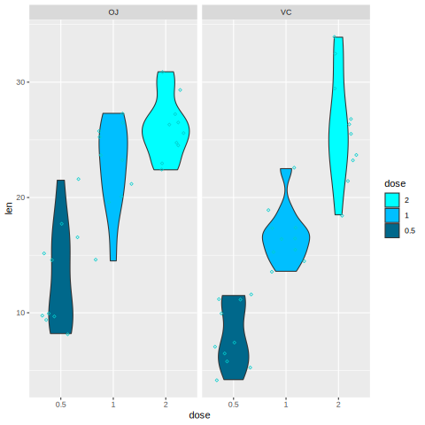

```ruby
violin = base_tooth +
   R.geom_violin(E.aes(fill: :dose)) +
   R.facet_grid(R[:all].til :supp) +
   R.geom_jitter(shape: 23, color: "cyan3", size: 1) +
   R.scale_fill_manual(
     values: R.c("cyan", "deepskyblue", "deepskyblue4"),
     breaks: R.c("2", "1", "0.5"))

puts violin
```

This plot is an alternative to the original boxplot. For the final presentation, it is important to think which graphics will be best understood by our audience. A violin plot is a less known plot and could add mental overhead, yet, in my opinion, it does look a lit bit better than the boxplot and provides even more information than the boxplot with jitter.

## 4.3 Adding Decoration

Our final plot is starting to take shape, but a presentation plot should have at least a title, labels on the axes and maybe some other decorations. Let’s start adding those. Since decoration requires more graph area, this new plot has a ‘width’ and ‘height’ specification. When there is no specification, the default values from R for width and height are 480.

The ‘labs’ function adds the required decoration. In this example we use ‘title’, ‘subtitle’, ‘x’ for the $x$ axis label and ‘y’, for the $y$ axis label, and ‘caption’ for information about the plot (for clarity, we defined a caption variable using Ruby’s Here Doc style).

```ruby
caption = <<-EOT
Length of odontoblasts in 60 guinea pigs.
Each animal received one of three dose levels of vitamin C.
EOT

decorations =
  R.labs(title: "Tooth Growth:  Length vs Vitamin C Dose",
         subtitle: "Faceted by delivery method, OJ or VC",
         x: "Dose (mg)", y: "Teeth length",
         caption: caption)

puts bp + decorations
```

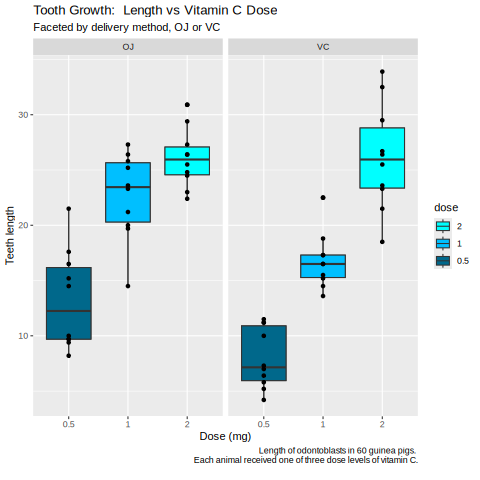

## 4.4 The Corp Theme

We are almost done. But the default plot configuration does not yet look nice to the eye. We are still distracted by many aspects of the graph. First, the back font color does not look good. Then plot background, borders, grids all add clutter to the plot.

We will now define our corporate theme. in a module that can be used/loaded for all plots, similar to CSS or any other style definition.

In this theme, we remove borders and grids. The background if left for faceted plots but removed for non-faceted plots. Font colors are a shade o blue (color: ‘#00080’). Axis labels are moved near the end of the axis and written in ‘bold’.

```ruby
module CorpTheme

  R.install_and_loads 'RColorBrewer'

  # ---------------------------------------------------------------
  # face: 1=plain, 2=bold, 3=italic, 4=bold-italic
  # ---------------------------------------------------------------

  def self.text_element(size, face: "plain", hjust: nil)
    E.element_text(color: "#000080",
                   face: face,
                   size: size,
                   hjust: hjust)
  end

  # ---------------------------------------------------------------
  # Plot theme: no major/minor grids or borders; optional
  # background for facets; turn off scientific notation.
  # ---------------------------------------------------------------

  def self.global_theme(faceted = false)

    R.options(scipen: 999)  # turn-off scientific notation like 1e+48
    # R.theme_set(R.theme_bw)

    # remove major grids
    gb = R.theme(panel__grid__major: E.element_blank())
    # remove minor grids
    gb = gb + R.theme(panel__grid__minor: E.element_blank)
    # remove border
    gb = gb + R.theme(panel__border: E.element_blank)
    # Keep background on faceted plots (helps separate facets)
    if !faceted
      gb = gb + R.theme(panel__background: E.element_blank)
    end
    # Change axis font
    gb = gb + R.theme(axis__text: text_element(8))
    # change axis title font
    gb = gb + R.theme(
      axis__title: text_element(10, face: "bold", hjust: 1))
    # change font of title
    gb = gb + R.theme(title: text_element(12, face: "bold"))
    # change font of subtitle
    gb = gb + R.theme(plot__subtitle: text_element(9))
    # change font of captions
    gb = gb + R.theme(plot__caption: text_element(8))

  end

end
```

## 4.5 Final Box Plot

We can now easily make our final boxplot and violin plot. All the layers for the plot were added in order to expose our understanding of the data and the need to present the result to our audience.

The final specification is just the addition of all layers build up to this point (‘bp’), plus the decorations (‘decorations’), plus the corporate theme.

Here is our final boxplot, without jitter.

```ruby
puts bp + decorations + CorpTheme.global_theme(faceted: true)
```

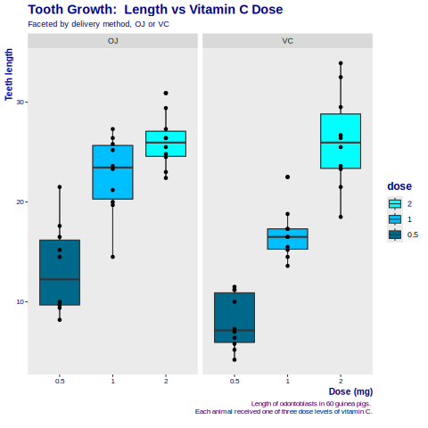

And here is the final violin plot, with jitter and the same look and feel of the corporate boxplot.

```ruby
puts violin + decorations + CorpTheme.global_theme(faceted: true)
```

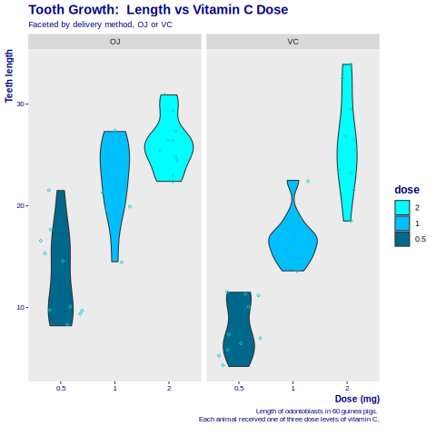

## 4.6 Another View

We now make another plot, with the same look and feel as before but facetted by dose and not by supplement. This shows how easy it is to create new plots by just changing small statement on the *grammar of graphics*.

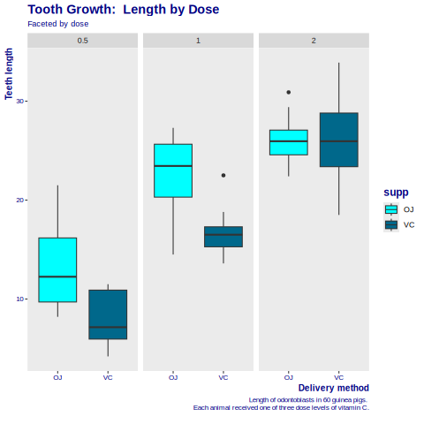

```ruby
caption = <<-EOT
Length of odontoblasts in 60 guinea pigs.
Each animal received one of three dose levels of vitamin C.
EOT

bp = tooth_growth.ggplot(
       E.aes(x: :supp, y: :len, group: :supp)) +
     R.geom_boxplot(E.aes(fill: :supp)) +
     R.facet_grid(R[:all].til :dose) +
     R.scale_fill_manual(
       values: R.c("cyan", "deepskyblue4")) +
     R.labs(title: "Tooth Growth:  Length by Dose",
            subtitle: "Faceted by dose",
            x: "Delivery method", y: "Teeth length",
            caption: caption) +
     CorpTheme.global_theme(faceted: true)

puts bp
```

# 5 Conclusion

In this article, we introduce Galaaz and show how to tightly couple Ruby and R in a way that Ruby developers do not need to be aware of the executing R engine. For the Ruby developer the existence of R is of no consequence, she is just coding in Ruby. On the other hand, for the R developer, migration to Ruby is a matter of small syntactic changes with a very gentle learning curve. As the R developer becomes more proficient in Ruby, he can start using ‘classes’, ‘modules’, ‘procs’, ‘lambdas’.

Trying to bring to Ruby the power of R starting from scratch is an enormous endeavour and would probably never be accomplished. Today’s data scientists would certainly stick with either Python or R. Now, both the Ruby and R communities can benefit from this marriage: **Galaaz 2.0** uses **standard GNU R** for statistics and graphics and **JRuby or CRuby** for application code (prefer **JRuby** when you want real threads and the JVM ecosystem). We presented the process to couple Ruby and R; the coupling is implemented by the Galaaz bridge and **gKnit** for literate documents, not by a single GraalVM polyglot runtime.

For performance, expect **ordinary GNU R** behaviour for model fitting and plotting, while **JRuby** can give **real parallel threads** on the Ruby side and access to Java libraries when you need them.

This article has shown how to improve a plot step-by-step. Starting from a very simple boxplot with all default configurations, we moved slowly to our final plot. The important point here is not if the final plot is actually beautiful (as beauty is in the eye of the beholder), but that there is a process of small steps improvements that can be followed to getting a final plot ready for presentation.

Finally, this whole article was written in rmarkdown and compiled to HTML by *gknit*, an application that wraps *knitr* and allows documenting Ruby code. This application can be of great help for any Rubyist trying to write articles, blogs or documentation for Ruby.

# 6 Installing Galaaz

## 6.1 Prerequisites (Galaaz 2.0)

- **JRuby** and a compatible **JDK**, *or* **CRuby 3.3+**
- **GNU R** — `R` on your `PATH`, with compilers/tools available if packages must be built from source

The following R packages will be automatically installed when necessary, but could be installed prior to using gKnit if desired:

- ggplot2
- gridExtra
- knitr

Installation of R packages requires a development environment and can be time consuming. On Linux, the usual build tools (e.g. a C/C++ compiler) are typically enough. On macOS, Xcode command-line tools are commonly required.

## 6.2 Preparation

- Install the **galaaz** gem (from RubyGems when published, or `gem build` / `path:` from a checkout).

## 6.3 Usage

- From the Galaaz repository (or your installed layout), render documents with **`bin/gknit`** (see the project manual for flags such as `--output_format all`).
- In Ruby code: `require 'galaaz'`
- Run Ruby with **`bin/galaaz-ruby`** (either engine) or **`bin/galaaz-jruby`** when you need JRuby JVM flags (see the manual).